```python
from nussl import jupyter_utils, AudioSignal
from wand.image import Image as WImage
import glob
import os

from IPython.core.display import display, HTML
display(HTML("<style>.container { width:65% !important; font-size:1em;}</style>"))

def _embed_audio(path):
    a = AudioSignal(path)
    jupyter_utils.embed_audio(a, display=True)

from IPython.display import HTML

HTML('''<script>
code_show=true;
function code_toggle() {
 if (code_show){
 $('div.input').hide();
 } else {
 $('div.input').show();
 }
 code_show = !code_show
}
$( document ).ready(code_toggle);
</script>
<form action="javascript:code_toggle()"><input type="submit" value="Click here to toggle on/off the raw code."></form>''')
```

# Figure 4.3

Performance of the best bootstrapped network ($\alpha=2$) vs performance of direction of arrival primitive used to train that network on the test set. Every dot represents a mixture in the test set. Points on the red line have equal performance by both approaches. Points to the right of the line mean the primitive out-performed the bootstrapped network. Points to the left of the line mean the bootstrapped network out-performed the primitive.

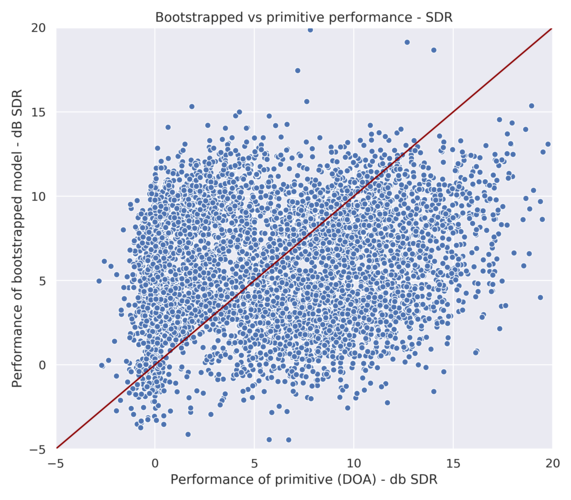

```python
img = WImage(filename='../bootstrap_vs_primitive_doa.png')
img.transform(resize='x500')
img
```

Below is an example of the bootstrapped model, the direction of arrival primitive, and a model that is trained from ground truth all run on the same mixture.

```python
print('Mixture')
_embed_audio('bootstrap_doa/mix.mp3')
print('\n')

print('Separation via direction of arrival')
_embed_audio('bootstrap_doa/spcl_0.mp3')
_embed_audio('bootstrap_doa/spcl_1.mp3')
print('\n')

print('Separation via bootstrapped model')
_embed_audio('bootstrap_doa/bs_dpcl_0.mp3')
_embed_audio('bootstrap_doa/bs_dpcl_1.mp3')
print('\n')

print('Separation via model trained from ground truth')
_embed_audio('bootstrap_doa/gt_dpcl_1.mp3')
_embed_audio('bootstrap_doa/gt_dpcl_0.mp3')
print('\n')
```

```
Mixture
```

[interactive chart not shown]

```
Separation via direction of arrival
```

[interactive chart not shown]

```
Separation via bootstrapped model
```

[interactive chart not shown]

```
Separation via model trained from ground truth
```

[interactive chart not shown]

# Figure 4.7

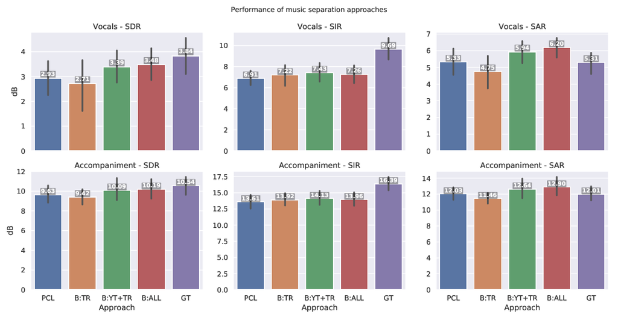

```python
WImage(filename='../bootstrap_pcl_comparison.pdf')
```

Below is an example separation via the bootstrapped model, primitive clustering (which it was trained from), and a model that is trained from ground truth all on the same mixture. All of these are done with *binary* masking to better hear the effect of separation and make for easier comparison between the methods.

```python
print('Mixture')
_embed_audio('bootstrap_pcl/mix.mp3')
print('\n')

print('Separation via primitive clustering (PCL)')
_embed_audio('bootstrap_pcl/pcl_bg.mp3')
_embed_audio('bootstrap_pcl/pcl_fg.mp3')
print('\n')

print('Separation via bootstrapped model (B:YT+TR)')
_embed_audio('bootstrap_pcl/bs_dpcl_bg.mp3')
_embed_audio('bootstrap_pcl/bs_dpcl_fg.mp3')
print('\n')

print('Separation via model trained from ground truth (GT)')
_embed_audio('bootstrap_pcl/gt_dpcl_bg.mp3')
_embed_audio('bootstrap_pcl/gt_dpcl_fg.mp3')
print('\n')
```

```
Mixture
```

[interactive chart not shown]

```
Separation via primitive clustering (PCL)
```

[interactive chart not shown]

```
Separation via bootstrapped model (B:YT+TR)
```

[interactive chart not shown]

```
Separation via model trained from ground truth (GT)
```

[interactive chart not shown]